# Exploratory Data Analysis — Olink Proteomic Data

Giulia Clas

2026-09-27

# 1 Introduction

This report presents an exploratory data analysis (EDA) of proteomic biomarker data from the **OlinkAnalyze** R package — the official open-source toolkit developed by [Olink Proteomics](https://olink.com/) (now part of Thermo Fisher Scientific).

The dataset (`npx_data1`) contains protein expression measurements in **NPX (Normalized Protein eXpression)** units (log2 scale) from a multi-site, longitudinal clinical study. It includes two Olink panels (**Inflammation** and **Cardiometabolic**), three timepoints (**Baseline**, **Week 6**, **Week 12**), and two treatment groups (**Treated** vs **Untreated**).

## 1.1 Load packages

```r
library(OlinkAnalyze)
library(dplyr)
library(ggplot2)
library(tidyr)
library(knitr)
```

## 1.2 Load data

```r
data(npx_data1)
```

# 2 Dataset Overview

```r
cat("Dimensions:", nrow(npx_data1), "rows ×", ncol(npx_data1), "columns\n")
```

```
## Dimensions: 29440 rows × 17 columns
```

```r
cat("Unique subjects:", length(unique(npx_data1$Subject)), "\n")
```

```
## Unique subjects: 53
```

```r
cat("Unique samples:", length(unique(npx_data1$SampleID)), "\n")
```

```
## Unique samples: 158
```

```r
cat("Unique proteins:", length(unique(npx_data1$Assay)), "\n")
```

```
## Unique proteins: 184
```

```r
tibble(
  Feature = c("Panels", "Treatments", "Timepoints", "Sites"),
  Values  = c(
    paste(unique(npx_data1$Panel), collapse = ", "),
    paste(unique(na.omit(npx_data1$Treatment)), collapse = ", "),
    paste(unique(na.omit(npx_data1$Time)), collapse = ", "),
    paste(unique(na.omit(npx_data1$Site)), collapse = ", ")
  )
) %>% kable()
```

| Feature | Values |
| --- | --- |
| Panels | Olink Cardiometabolic, Olink Inflammation |
| Treatments | Untreated, Treated |
| Timepoints | Baseline, Week.6, Week.12 |
| Sites | Site_D, Site_C, Site_B, Site_E, Site_A |

## 2.1 Study design

```r
# Subjects per Treatment × Timepoint
npx_data1 %>%
  filter(!is.na(Treatment), !is.na(Time)) %>%
  distinct(Subject, Treatment, Time) %>%
  count(Treatment, Time) %>%
  pivot_wider(names_from = Time, values_from = n) %>%
  kable(caption = "Number of subjects per Treatment × Timepoint")
```

Number of subjects per Treatment × Timepoint

| Treatment | Baseline | Week.12 | Week.6 |
| --- | --- | --- | --- |
| Treated | 23 | 23 | 23 |
| Untreated | 29 | 29 | 29 |

```r
# Subjects per Site
npx_data1 %>%
  filter(!is.na(Site)) %>%
  distinct(Subject, Site) %>%
  count(Site) %>%
  kable(caption = "Number of subjects per clinical site")
```

Number of subjects per clinical site

| Site | n |
| --- | --- |
| Site_A | 8 |
| Site_B | 11 |
| Site_C | 11 |
| Site_D | 10 |
| Site_E | 12 |

# 3 Quality Control

## 3.1 QC Warning rates

Olink flags each measurement with a quality control status. “Pass” means the sample passed all internal controls; “Warning” indicates potential issues.

```r
npx_data1 %>%
  group_by(Panel) %>%
  summarise(
    Total    = n(),
    Warnings = sum(QC_Warning == "Warning"),
    `% Warning` = round(100 * Warnings / Total, 2),
    .groups = "drop"
  ) %>%
  kable(caption = "QC Warning rates by panel")
```

QC Warning rates by panel

| Panel | Total | Warnings | % Warning |
| --- | --- | --- | --- |
| Olink Cardiometabolic | 14720 | 92 | 0.62 |
| Olink Inflammation | 14720 | 184 | 1.25 |

## 3.2 Sample-level QC plot

This plot shows each sample’s median NPX vs IQR across all assays. Outlier samples deviate substantially from the expected range.

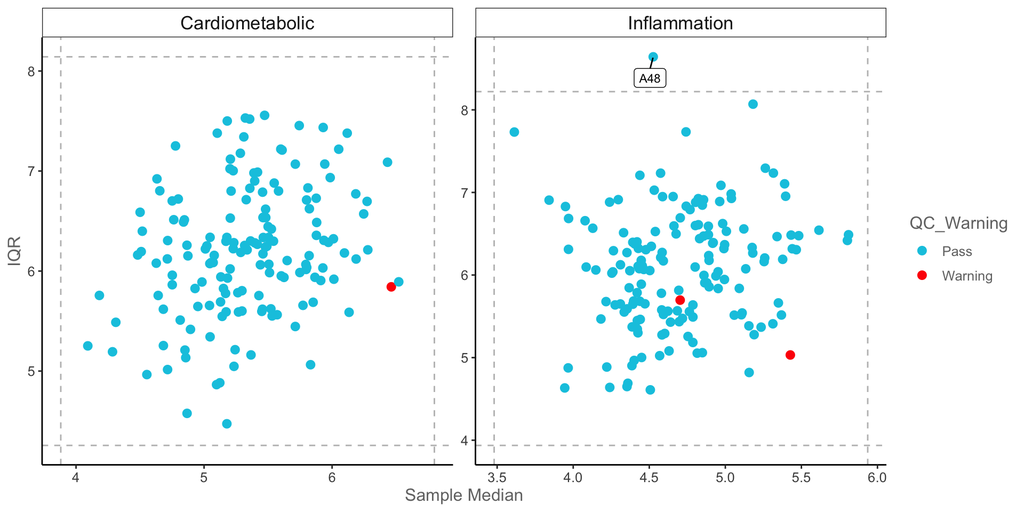

```r
olink_qc_plot(npx_data1, color_g = "QC_Warning")
```

## 3.3 Plate distributions

Comparing NPX distributions across plates helps detect potential **batch effects**.

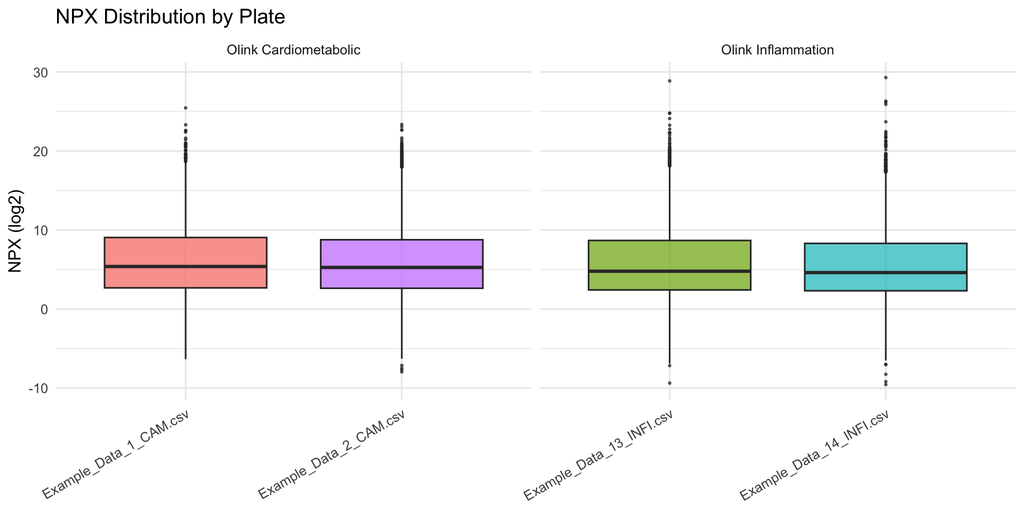

```r
ggplot(npx_data1, aes(x = PlateID, y = NPX, fill = PlateID)) +
  geom_boxplot(alpha = 0.7, outlier.size = 0.5) +
  facet_wrap(~Panel, scales = "free_x") +
  labs(title = "NPX Distribution by Plate",
       y = "NPX (log2)", x = NULL) +
  theme_minimal(base_size = 12) +
  theme(axis.text.x = element_text(angle = 30, hjust = 1),
        legend.position = "none")
```

## 3.4 Limit of Detection (LOD)

LOD is the NPX threshold below which measurements are considered unreliable. **MissingFreq** reports the fraction of samples below LOD for each assay.

```r
cat("LOD summary:\n")
```

```
## LOD summary:
```

```r
summary(npx_data1$LOD)
```

```
##    Min. 1st Qu.  Median    Mean 3rd Qu.    Max.
## -5.1273  0.0000  0.4288  0.9440  1.5687  6.4499
```

```r
cat("\nMissing Frequency summary:\n")
```

```
##
## Missing Frequency summary:
```

```r
summary(npx_data1$MissingFreq)
```

```
##    Min. 1st Qu.  Median    Mean 3rd Qu.    Max.
## 0.00625 0.02500 0.05625 0.05268 0.07500 0.10000
```

```r
npx_data1 %>%
  distinct(Assay, Panel, MissingFreq) %>%
  arrange(desc(MissingFreq)) %>%
  head(10) %>%
  kable(caption = "Top 10 proteins with highest missing frequency")
```

Top 10 proteins with highest missing frequency

| Assay | Panel | MissingFreq |
| --- | --- | --- |
| F11 | Olink Cardiometabolic | 0.10000 |
| MET | Olink Cardiometabolic | 0.10000 |
| SPARCL1 | Olink Cardiometabolic | 0.10000 |
| IL-15RA | Olink Inflammation | 0.10000 |
| TNFB | Olink Inflammation | 0.10000 |
| LILRB5 | Olink Cardiometabolic | 0.09375 |
| C2 | Olink Cardiometabolic | 0.09375 |
| TNXB | Olink Cardiometabolic | 0.09375 |
| TGFBI | Olink Cardiometabolic | 0.09375 |
| CNDP1 | Olink Cardiometabolic | 0.09375 |

# 4 NPX Distribution

## 4.1 By Treatment group

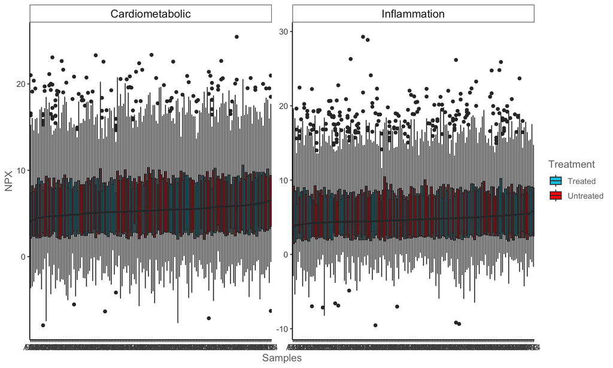

```r
npx_treated <- npx_data1 %>% filter(!is.na(Treatment))
olink_dist_plot(npx_treated, color_g = "Treatment")
```

## 4.2 By Panel

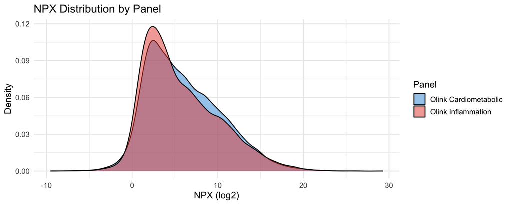

```r
ggplot(npx_data1, aes(x = NPX, fill = Panel)) +
  geom_density(alpha = 0.5) +
  labs(title = "NPX Distribution by Panel",
       x = "NPX (log2)", y = "Density") +
  theme_minimal(base_size = 13) +
  scale_fill_manual(values = c("#3498DB", "#E74C3C"))
```

# 5 Dimensionality Reduction

We apply PCA and UMAP to the full proteomics matrix to explore sample clustering. Samples are colored by different clinical variables to identify potential structure in the data.

```r
# Use only clinical subjects (exclude plate controls)
npx_subjects <- npx_data1 %>%
  filter(!is.na(Treatment), !is.na(Time))
```

## 5.1 PCA — by Treatment

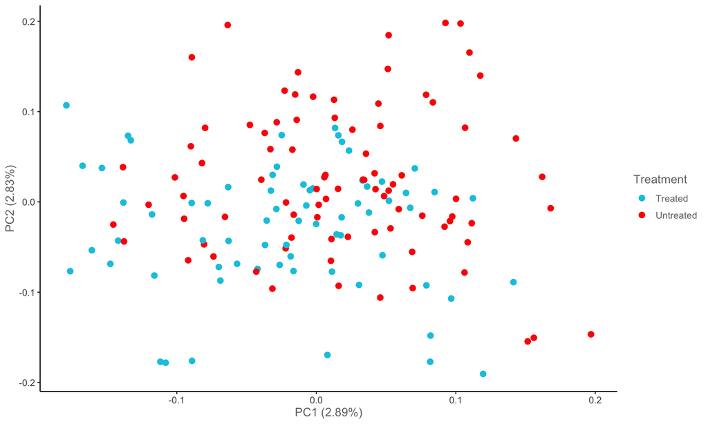

```r
olink_pca_plot(npx_subjects, color_g = "Treatment", quiet = TRUE)[[1]]
```

## 5.2 PCA — by Timepoint

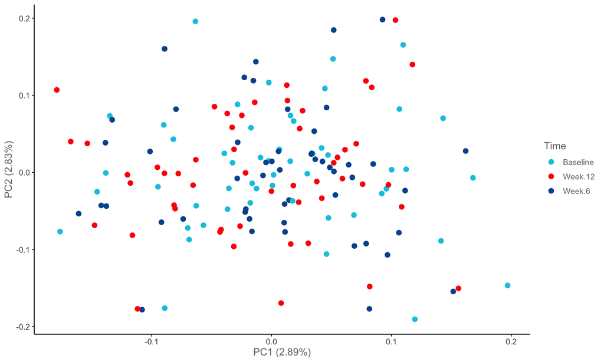

```r
olink_pca_plot(npx_subjects, color_g = "Time", quiet = TRUE)[[1]]
```

## 5.3 PCA — by Site

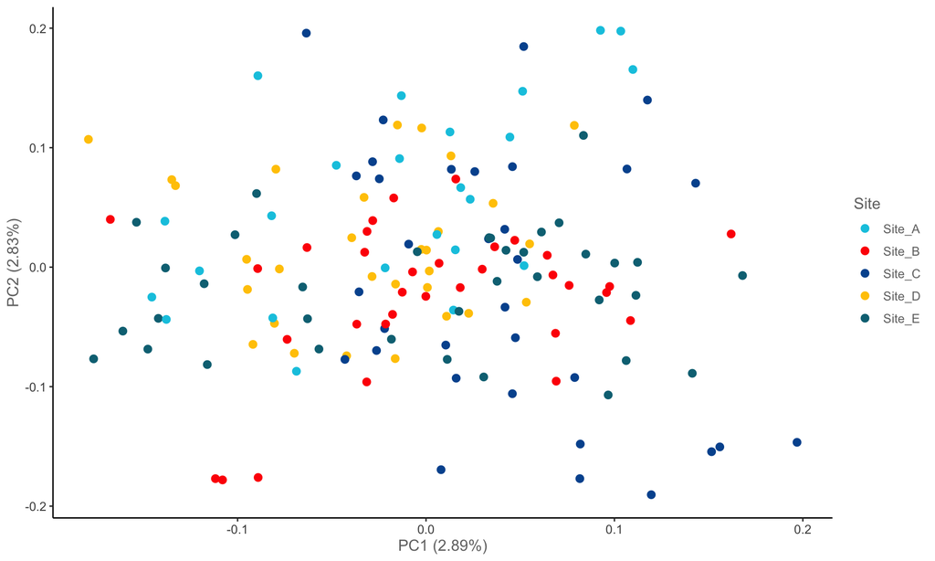

```r
olink_pca_plot(npx_subjects, color_g = "Site", quiet = TRUE)[[1]]
```

## 5.4 UMAP — by Treatment

UMAP is a non-linear dimensionality reduction method that can reveal clusters that PCA might miss.

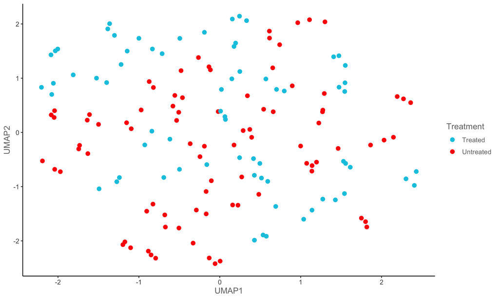

```r
olink_umap_plot(npx_subjects, color_g = "Treatment", quiet = TRUE)[[1]]
```

# 6 Statistical Testing

We compare protein levels between **Treated** and **Untreated** groups at **Baseline** (before treatment). At Baseline, we expect **no significant differences** if randomization was successful.

```r
npx_baseline <- npx_data1 %>%
  filter(!is.na(Treatment), Time == "Baseline")
```

## 6.1 Wilcoxon rank-sum test

We use the non-parametric **Wilcoxon rank-sum test** (Mann-Whitney U), which does not assume normality — a conservative and appropriate choice for biomarker data.

The `olink_wilcox()` function automatically applies **Benjamini-Hochberg FDR correction** for multiple testing across all proteins.

```r
wilcox_results <- olink_wilcox(npx_baseline, variable = "Treatment")

cat("Total proteins tested:", nrow(wilcox_results), "\n")
```

```
## Total proteins tested: 184
```

```r
cat("Significant (p < 0.05):",
    sum(wilcox_results$p.value < 0.05, na.rm = TRUE), "\n")
```

```
## Significant (p < 0.05): 15
```

```r
cat("Significant after FDR correction (Adjusted p < 0.05):",
    sum(wilcox_results$Adjusted_pval < 0.05, na.rm = TRUE), "\n")
```

```
## Significant after FDR correction (Adjusted p < 0.05): 0
```

### 6.1.1 Top proteins by adjusted p-value

```r
wilcox_results %>%
  arrange(Adjusted_pval) %>%
  head(15) %>%
  select(Assay, estimate, p.value, Adjusted_pval) %>%
  mutate(
    p.value = format(p.value, digits = 3, scientific = TRUE),
    Adjusted_pval = round(Adjusted_pval, 4)
  ) %>%
  kable(caption = "Top 15 proteins ranked by FDR-adjusted p-value")
```

Top 15 proteins ranked by FDR-adjusted p-value

| Assay | estimate | p.value | Adjusted_pval |
| --- | --- | --- | --- |
| MMP-10 | -3.1795363 | 1.18e-03 | 0.2171 |
| Flt3L | 2.6741176 | 6.79e-03 | 0.3883 |
| IFN-gamma | -2.2601816 | 8.08e-03 | 0.3883 |
| TWEAK | -2.3823854 | 8.56e-03 | 0.3883 |
| CD6 | 1.0573801 | 1.07e-02 | 0.3883 |
| C2 | 3.0188506 | 1.27e-02 | 0.3883 |
| DPP4 | -2.4659340 | 1.49e-02 | 0.3912 |
| LAP TGF-beta-1 | 0.4583832 | 1.74e-02 | 0.4010 |
| SLAMF1 | -2.4387097 | 2.88e-02 | 0.5894 |
| TRAIL | -1.8827546 | 3.33e-02 | 0.5896 |
| IL-17A | 3.1383736 | 3.66e-02 | 0.5896 |
| PTPRS | 1.9541544 | 4.20e-02 | 0.5896 |
| UMOD | -2.3343707 | 4.20e-02 | 0.5896 |
| SAA4 | 2.2344932 | 4.60e-02 | 0.5896 |
| IL-22 RA1 | -3.1206519 | 4.81e-02 | 0.5896 |

## 6.2 Volcano plot

The volcano plot shows **effect size** (x-axis) vs **statistical significance** (y-axis, −log10 p-value) for all proteins. The dashed line indicates the p = 0.05 threshold.

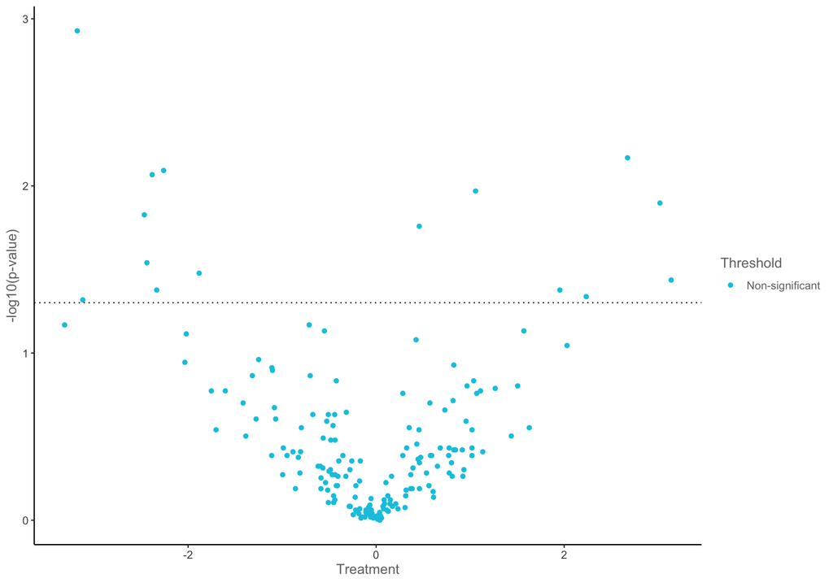

```r
olink_volcano_plot(wilcox_results, x_lab = "Treatment")
```

> **Interpretation:** No proteins survive FDR correction at Baseline, which is the expected result — it confirms that the randomization was successful and there are no systematic pre-treatment differences between groups.

# 7 Summary

| Metric | Value |
| --- | --- |
| Total proteins | 184 |
| Subjects | 53 |
| Panels | Olink Cardiometabolic, Olink Inflammation |
| QC Warning rate (Inflammation) | 1.25% |
| Proteins with p < 0.05 at Baseline | 15 |
| Proteins significant after FDR | 0 |

*Report generated with OlinkAnalyze 4.5.0 and R 4.4.2.*